# ps5

Sijun Zhang

2019/12/1

# Question 1

```r
library(data.table)

# read in the  data: -----------------------------------------------------------
## This data will be used in the question.
url_base <- 'https://www.eia.gov/consumption/residential/data/2015/csv/'

recs_file <- './recs2015_public_v4.csv'
if ( !file.exists(recs_file) ) {
  recs_url <- sprintf('%s/recs2015_public_v4.csv', url_base)
  recs <- readr::read_delim(recs_url, delim = ',')
  readr::write_delim(recs, path = recs_file, delim = ',')
} else {
  recs <- readr::read_delim(recs_file, delim = ',')
}
recs = data.table(recs)

decode_division = function(x) {
  if(!is.numeric(x)) stop('decode_divsion expects numeric input indexed from 1!')
  y <- x
  re <- switch (y,
                'New England',
                'Middle Atlantic',
                'East North Central',
                'West North Central',
                'South Atlantic',
                'East South Central',
                'West South Central',
                'Mountain North',
                'Mountain South',
                'Pacific')
  return(re)
}

decode_all_division = function(x) {
  return(sapply(x,decode_division))
}

collapse_UC = function(x) {
  if (x == "C") {re <- "U"}
  else {re <- x}
  return(re)
}

collapse_all_UC = function(x) {
  sapply(x, collapse_UC)
}

# Key values for each observation: --------------------------------------------
internet_recs <- recs[, .(DOEID = DOEID, dvi = decode_all_division(DIVISION),
                          utype = collapse_all_UC(UATYP10),
                          internet = INTERNET, weight = NWEIGHT)]

# Convert weights to long: ----------------------------------------------------
brrwts = names(recs)[which(names(recs) == "BRRWT1"):
                       which(names(recs) == "BRRWT96")]

weights_long <- recs[, .SD, .SDcols = c(1, which(names(recs) == "BRRWT1"):
                                          which(names(recs) == "BRRWT96"))]
weights_long <- melt(weights_long, id.vars = c("DOEID"), measure.vars = brrwts)

# Join home type to weights: --------------------------------------------------
internet_weighted <- merge(weights_long, internet_recs, by='DOEID', all.x = TRUE)

if( nrow(weights_long) != nrow(internet_weighted) ) {
  stop("DOEID mismatch!")
}

internet_weighted <- internet_weighted[, `:=`(brrwt_with_internet = internet*value,
                                              nw_with_internet = internet*weight)
                     ][, .(brrwt = sum(value), nweight = sum(weight),
                       nw_with_internet = sum(nw_with_internet),
                       brrwt_with_internet = sum(brrwt_with_internet),
                       repl = variable), by=.(dvi, utype, variable)
                     ][, `:=`(prop_repl = brrwt_with_internet/brrwt,
                       prop = nw_with_internet/nweight)
                     ][, .(dvi, utype, repl, prop_repl, prop)]


# calc the confidence interval using brrwt replications
internet_weighted <- dcast(internet_weighted, dvi+repl~utype, value.var=c("prop_repl","prop") )

internet_weighted_ci <-  internet_weighted[, `:=`(diff_prop = prop_U-prop_R,
                                                  diff_prop_repl = prop_repl_U-prop_repl_R)
                         ][, `:=`(rsq_prop1 = (prop_U-prop_repl_U)^2/(1-0.5)^2,
                           rsq_prop2 = (prop_R-prop_repl_R)^2/(1-0.5)^2,
                           rsq_prop_diff = (diff_prop-diff_prop_repl)^2/(1-0.5)^2)
                         ][, .(prop_U = mean(prop_U),  prop_R = mean(prop_R),
                           diff_prop = mean(diff_prop), stderr_prop1 = sqrt(mean(rsq_prop1)),
                           stderr_prop2 = sqrt(mean(rsq_prop2)),
                           stderr_prop_diff = sqrt(mean(rsq_prop_diff))), by = .(dvi)
                         ][, `:=`(diff_prop_lwr = diff_prop - 1.96*(stderr_prop_diff),
                           diff_prop_upr = diff_prop + 1.96*(stderr_prop_diff))
                         ][order(-diff_prop)]

# tabling
options(digits = 4)
knitr::kable(internet_weighted_ci)
```

| dvi | prop_U | prop_R | diff_prop | stderr_prop1 | stderr_prop2 | stderr_prop_diff | diff_prop_lwr | diff_prop_upr |
| --- | --- | --- | --- | --- | --- | --- | --- | --- |
| Mountain South | 0.8527 | 0.6675 | 0.1852 | 0.0201 | 0.0433 | 0.0578 | 0.0719 | 0.2984 |
| East South Central | 0.7836 | 0.6903 | 0.0933 | 0.0399 | 0.0282 | 0.0547 | -0.0140 | 0.2006 |
| West North Central | 0.8800 | 0.8033 | 0.0768 | 0.0172 | 0.0451 | 0.0517 | -0.0245 | 0.1781 |
| Mountain North | 0.8742 | 0.8193 | 0.0550 | 0.0277 | 0.0414 | 0.0596 | -0.0619 | 0.1719 |
| West South Central | 0.8161 | 0.7650 | 0.0510 | 0.0265 | 0.0223 | 0.0377 | -0.0230 | 0.1250 |
| Pacific | 0.8871 | 0.8528 | 0.0343 | 0.0129 | 0.0400 | 0.0405 | -0.0451 | 0.1137 |
| South Atlantic | 0.8530 | 0.8204 | 0.0326 | 0.0136 | 0.0294 | 0.0347 | -0.0354 | 0.1005 |
| New England | 0.8757 | 0.8579 | 0.0178 | 0.0259 | 0.0175 | 0.0218 | -0.0248 | 0.0604 |
| East North Central | 0.8625 | 0.8621 | 0.0004 | 0.0127 | 0.0233 | 0.0273 | -0.0530 | 0.0539 |
| Middle Atlantic | 0.8934 | 0.9129 | -0.0195 | 0.0280 | 0.0305 | 0.0364 | -0.0909 | 0.0519 |

```r
internet_weighted_ci[which( internet_weighted_ci[,"diff_prop"] == max(internet_weighted_ci[,"diff_prop"])),1]
```

```
##               dvi
## 1: Mountain South
```

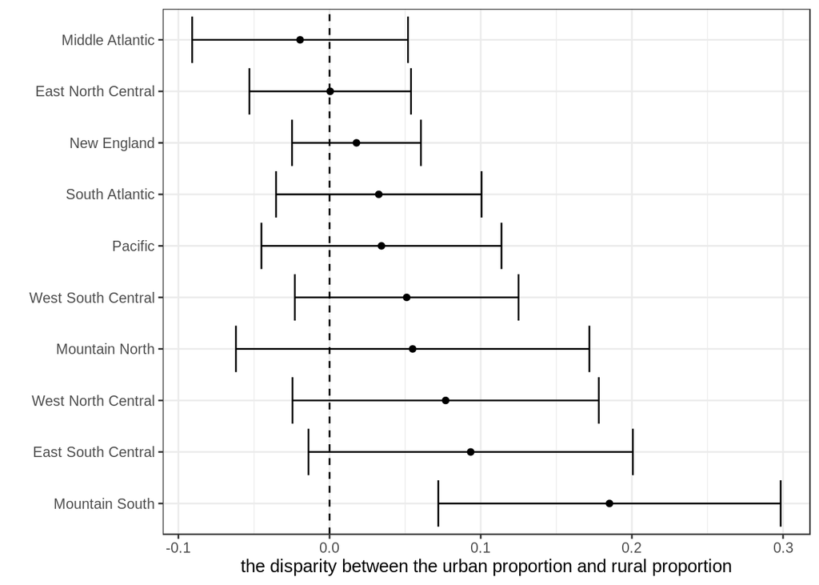

```r
# graphing
library(ggplot2)
graph_tmp = internet_weighted_ci[,`:=`(measure = factor(dvi, levels = unique(dvi) ))]

ggplot(graph_tmp, aes( y = measure, x = diff_prop) ) +
  geom_point() +
  geom_errorbarh( aes(xmin = diff_prop_lwr, xmax = diff_prop_upr) ) +
  geom_vline( xintercept = 0, lty = 'dashed') +
  xlab('the disparity between the urban proportion and rural proportion') +
  ylab('') +
  theme_bw()
```

From the above table, prop_urb shows the proportion of home with internet in urban area, prop_rur shows the proportion of home with internet in rural area and diff_prop shows the disparity between the urban proportion and rural proportion. Each of them has been obtained 95% confidence inerval which is shown above. From the diff_prop columns, we can find the “Mountain South” census division has the largest disparity between urban and rural areas in terms of the proportion of homes with internet access.

# Question 2

## Part a

```
#!/bin/bash
#--------------------------------------------
# author：Sijun Zhang umid:89934761 randyz@umich.edu
# last change date: 12/1/2019
#--------------------------------------------

# Download the data and inspect the first 100 rows at the command line.
file="GSE138311_series_matrix.txt"
if [ ! -f "$file" ]; then
    wget ftp://ftp.ncbi.nlm.nih.gov/geo/series/GSE138nnn/GSE138311/matrix/GSE138311_series_matrix.txt.gz
    gunzip GSE138311_series_matrix.txt.gz
fi

head --line=100 $file

# Write the commands for doing so in your solution. How many lines of header information are there?
head --line=100 $file > GSE138311_series_matrix_head100.txt
grep -rn -o -E "\"ID_REF\"" GSE138311_series_matrix_head100.txt | tr ":" "\n" | awk 'NR%2 ==1'
```

The result shows that there are 69 lines used for header information that includes one line for colnames. In other words, if the colnames line is not treated as the header, then we have 68 lines of header.

## Part b

```r
library(data.table)
library(ggplot2)
gse = fread("GSE138311_series_matrix.txt", skip = 68)
gse_b = gse[grep("^ch", ID_REF),
        ][, -("GSM4105199"), with = FALSE]
gse_b = melt(gse_b, id.vars = c("ID_REF"))

head(gse_b)
```

```
##             ID_REF   variable   value
## 1: ch.1.101940785F GSM4105187 0.04272
## 2:   ch.1.1021960F GSM4105187 0.11388
## 3:   ch.1.1026209F GSM4105187 0.06742
## 4: ch.1.103396251R GSM4105187 0.10374
## 5:   ch.1.1047298R GSM4105187 0.04844
## 6: ch.1.107099706F GSM4105187 0.06505
```

We can see each row reperesent a sample-probe pair.

## Part c

```r
#c. label the diseased sample as sample_group 1 and the other as 0
label_disease = function(x) {
  if (x %in% c("GSM4105187", "GSM4105188", "GSM4105189",
               "GSM4105190", "GSM4105191", "GSM4105192",
               "GSM4105193")) { re = 1}
  else {re = 0}
  return(re)
}

label_disease_all = function(x) {
  return(sapply(x,label_disease))
}

gse_c = gse_b[, `:=`(sample_group = label_disease_all(variable))]
head(gse_c)
```

```
##             ID_REF   variable   value sample_group
## 1: ch.1.101940785F GSM4105187 0.04272            1
## 2:   ch.1.1021960F GSM4105187 0.11388            1
## 3:   ch.1.1026209F GSM4105187 0.06742            1
## 4: ch.1.103396251R GSM4105187 0.10374            1
## 5:   ch.1.1047298R GSM4105187 0.04844            1
## 6: ch.1.107099706F GSM4105187 0.06505            1
```

Label the diseased sample as sample_group 1 and the other as 0

## Part d

```r
calc_t = function(mu,n,s) {
  sp = sqrt( ((n[1]-1)*(s[1])^2 + (n[2]-1)*(s[2])^2 ) / (sum(n)-2) )
  se = sp * sqrt(1/n[1] + 1/n[2])
  t = (mu[1] - mu[2]) / se
  return(t)
}

gse_d = gse_c[, .(mu = mean(value), n = .N, s = sd(value)), by=.(ID_REF, sample_group)
        ][, .(t_score = calc_t(mu,n,s)), by=.(ID_REF) ]
head(gse_d)
```

```
##             ID_REF t_score
## 1: ch.1.101940785F -0.5317
## 2:   ch.1.1021960F  1.0065
## 3:   ch.1.1026209F  0.9559
## 4: ch.1.103396251R  2.2946
## 5:   ch.1.1047298R  0.9773
## 6: ch.1.107099706F  1.1423
```

## Part e

```r
gse_e = gse_d[,`:=`(probe_group = substr(ID_REF,  1, 5))]
```

## Part f

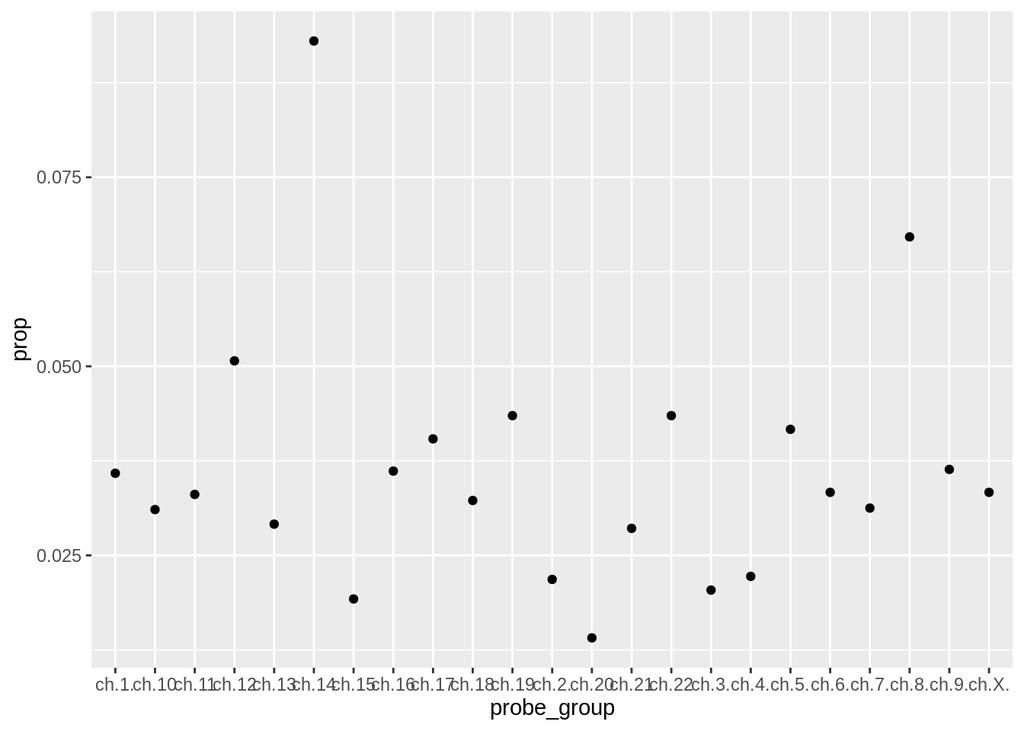

```r
gse_f = gse_e[, `:=`(critical_abs_value = qt(0.975, df=10))
        ][, `:=`(index = (abs(t_score) > critical_abs_value))
        ][, .(prop = sum(index) / .N), by=.(probe_group)]

ggplot(gse_f, aes(x = probe_group, y = prop)) +
  geom_point()
```

From the graph, we can find the probe_group “ch.14”, “ch.12” and “ch.8” stands out as potentially over-represented as the proportions of them are greater than 0.05

## Part g

```r
# declare the sample_id for reference
crohn_ind = append(rep(1,7), rep(0,5))
sample_id = c("GSM4105187", "GSM4105188", "GSM4105189",
              "GSM4105190", "GSM4105191", "GSM4105192","GSM4105193",
              "GSM4105194", "GSM4105195", "GSM4105196", "GSM4105197", "GSM4105198")

permutation_test = function(df, type = "two-tailed",
                            permuate = TRUE, alpha = 0.05){
  if (!permuate){
    # same process in d.
    df_est = df[, .(mu = mean(value), n = .N, s = sd(value)), by=.(ID_REF, sample_group)
                ][, .(t_score = calc_t(mu,n,s)), by=.(ID_REF)
                  ][,`:=`(probe_group = substr(ID_REF,  1, 5))]
  }
  if (permuate){
    # permutate the sample_group using merge
    sample_group = sample(crohn_ind, size = 12, replace = FALSE)
    sample_group_table = data.table(cbind(sample_id ,sample_group))
    df_est = df[, .(ID_REF, sample_id = variable,value)]
    # give the df permuated sample_group
    df_est = merge(df_est,sample_group_table, by = 'sample_id', all.x = TRUE)
    df_est = df_est[, .(mu = mean(value), n = .N, s = sd(value)), by=.(ID_REF, sample_group)
                    ][, .(t_score = calc_t(mu,n,s)), by=.(ID_REF)
                      ][,`:=`(probe_group = substr(ID_REF,  1, 5))]
  }
  if(type == "two-tailed"){
    df_est = df_est[, `:=`(index = (abs(t_score) > qt(1-alpha/2, df=10)))
                    ][, .(T_abs = mean(index*abs(t_score))), by=.(probe_group)]
  } else if (type == "greater"){
    df_est = df_est[, `:=`(index = ((t_score) > qt(1-alpha, df=10)))
                    ][, .(T_up = mean(index*(t_score))), by=.(probe_group)]
  } else {
    df_est = df_est[, `:=`(index = ((t_score) < qt(alpha, df=10)))
                    ][, .(T_down = mean(index*(t_score))), by=.(probe_group)]
  }
  return(df_est)
}
```

The basic idea in the permuating process is to shuffle (sample w/o replacement) either the 12 sample ids or the 12 Crohn’s/Not-Crohn’s labels and use merge to give the permuated group label to each sample.

## Part h

In the following part, we apply the guide in resampling techniques and add one to both the numerator and denominator.

```r
set.seed(5)
T_abs_original = permutation_test(gse_c, type = "two-tailed", permuate = FALSE)
p_value_index = T_abs_original[, .(probe_group, ind = 0)]
start_time=Sys.time()
for (i in 1:1000) {
  T_abs_permuated = permutation_test(gse_c, type = "two-tailed", permuate = TRUE)
  p_value_index_i = merge(T_abs_permuated, T_abs_original,
                          all.x = TRUE, by='probe_group')
  # calc whether the observed Tabs score for each group is larger than the expectation
  p_value_index_i = p_value_index_i[,.(probe_group, ind_i = T_abs.x >= T_abs.y)]
  # cumulating the larger or not result
  p_value_index = merge(p_value_index, p_value_index_i, all.x = TRUE, by='probe_group')[
    ,.(probe_group,ind = ind+ind_i)]
}
end_time=Sys.time()
for_loop_time = end_time-start_time
p_value_index = p_value_index[, .(probe_group, p_value = (ind+1)/1001)]
cat("The time taken to compute 1,000 permutation in for-loop is shown below \n")
```

```
## The time taken to compute 1,000 permutation in for-loop is shown below
```

```r
for_loop_time
```

```
## Time difference of 22.23 secs
```

```r
knitr::kable(p_value_index)
```

| probe_group | p_value |
| --- | --- |
| ch.1. | 0.5145 |
| ch.10 | 0.4905 |
| ch.11 | 0.4985 |
| ch.12 | 0.2557 |
| ch.13 | 0.6164 |
| ch.14 | 0.0849 |
| ch.15 | 0.6344 |
| ch.16 | 0.4186 |
| ch.17 | 0.4855 |
| ch.18 | 0.6513 |
| ch.19 | 0.4276 |
| ch.2. | 0.7273 |
| ch.20 | 0.7972 |
| ch.21 | 0.5594 |
| ch.22 | 0.4236 |
| ch.3. | 0.7233 |
| ch.4. | 0.5245 |
| ch.5. | 0.4126 |
| ch.6. | 0.5095 |
| ch.7. | 0.6124 |
| ch.8. | 0.1878 |
| ch.9. | 0.5814 |
| ch.X. | 0.5035 |

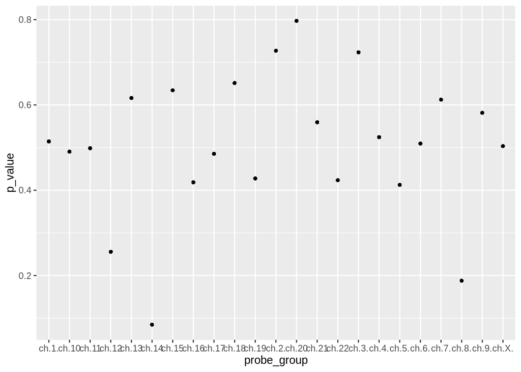

```r
ggplot(p_value_index, aes(x = probe_group, y = p_value)) +
  geom_point(shape=16)
```

From the graph, we can find the ch.14 gene group has the p-value = 0.0849151, where we can approximately reject the null hypothesis at most significant level = 0.0849. However, at 0.05 level, we can not reject null hypothesis in any group.

## Part i

```r
library(parallel)
set.seed(6925)
p_value_index = T_abs_original[, .(probe_group, ind = 0)]
T_up_original = permutation_test(gse_c, type = "greater", permuate = FALSE)
permutating_T_up = function(i, x) {
  T_up_permuated = permutation_test(x, type = "greater", permuate = TRUE)
  return(T_up_permuated)
}
# parallel computing the T_up
start_time=Sys.time()
T_up_permuated_all = mclapply(1:1000, permutating_T_up, x=gse_c)
end_time=Sys.time()
# calc the p_value
for (i in 1:1000) {
  T_up_permuated = T_up_permuated_all[[i]]
  p_value_index_i = merge(T_up_permuated, T_up_original,
                          all.x = TRUE, by='probe_group')
  # calc whether the observed Tup score for each group is larger than the expectation
  p_value_index_i = p_value_index_i[,.(probe_group, ind_i = T_up.x >= T_up.y)]
  # cumulating the larger or not result
  p_value_index = merge(p_value_index, p_value_index_i, all.x = TRUE, by='probe_group')[
    ,.(probe_group,ind = ind+ind_i)]
}
mclapply_time = end_time-start_time
p_value_index = p_value_index[, .(probe_group, p_value = (ind+1)/1001)]
cat("The time taken to compute 1,000 permutation in mclapply_time is shown below \n")
```

```
## The time taken to compute 1,000 permutation in mclapply_time is shown below
```

```r
mclapply_time
```

```
## Time difference of 8.169 secs
```

```r
knitr::kable(p_value_index)
```

| probe_group | p_value |
| --- | --- |
| ch.1. | 0.0939 |
| ch.10 | 0.1449 |
| ch.11 | 0.2148 |
| ch.12 | 0.0939 |
| ch.13 | 0.0699 |
| ch.14 | 0.0260 |
| ch.15 | 0.1009 |
| ch.16 | 0.0809 |
| ch.17 | 0.1918 |
| ch.18 | 0.1958 |
| ch.19 | 0.1329 |
| ch.2. | 0.3197 |
| ch.20 | 0.1499 |
| ch.21 | 0.2717 |
| ch.22 | 0.2068 |
| ch.3. | 0.2378 |
| ch.4. | 0.1119 |
| ch.5. | 0.1019 |
| ch.6. | 0.1489 |
| ch.7. | 0.1698 |
| ch.8. | 0.1099 |
| ch.9. | 0.1778 |
| ch.X. | 0.1069 |

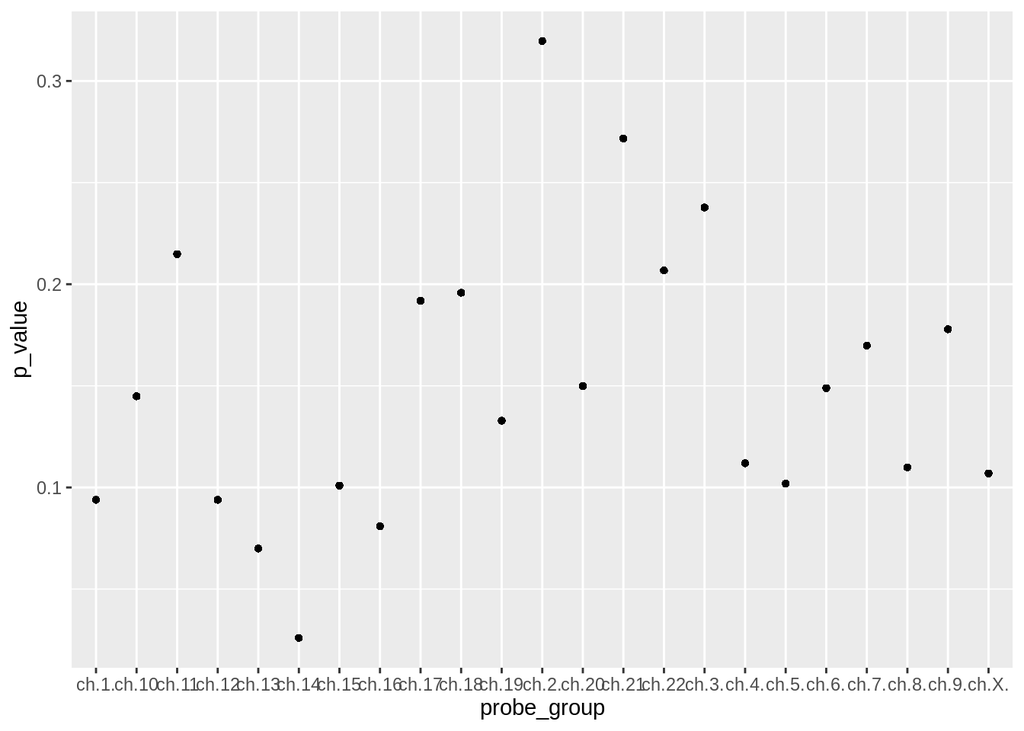

```r
ggplot(p_value_index, aes(x = probe_group, y = p_value)) +
  geom_point(shape=16)
```

## Part j

```r
#j. split the task into 2 sub-task using future
library(future)
plan(multisession)
set.seed(6925)
p_value_index = T_abs_original[, .(probe_group, ind = 0)]
T_down_original = permutation_test(gse_c, type = "lesser", permuate = FALSE)
permutating_T_down = function(x) {
  T_down_permuated = permutation_test(x, type = "lesser", permuate = TRUE)
  return(T_down_permuated)
}
# parallel computing the T_down
start_time=Sys.time()
T_up_permuated_all_1 %<-% {
  c = list()
  for (i in 1:500) {c[[i]] = permutating_T_down(gse_c)}
  c
}
T_up_permuated_all_2 %<-% {
  c = list()
  for (i in 1:500) {c[[i]] = permutating_T_down(gse_c)}
  c
}
T_down_permuated_all = c(T_up_permuated_all_1, T_up_permuated_all_2)
end_time=Sys.time()
future_time = end_time - start_time
# calc the p_value
for (i in 1:1000) {
  T_down_permuated = T_down_permuated_all[[i]]
  p_value_index_i = merge(T_down_permuated, T_down_original,
                          all.x = TRUE, by='probe_group')
  # calc whether the observed Tup score for each group is larger than the expectation
  # according to the resampling method, as the value of T_down all smaller than or equal to 0
  # and the p_est compare the absolute value of statistics, we change the >= to <= here.
  p_value_index_i = p_value_index_i[,.(probe_group, ind_i = T_down.x <= T_down.y)]
  # cumulating the larger or not result
  p_value_index = merge(p_value_index, p_value_index_i, all.x = TRUE, by='probe_group')[
    ,.(probe_group,ind = ind+ind_i)]
}
p_value_index = p_value_index[, .(probe_group, p_value = (ind+1)/1001)]
cat("The time taken to compute 1,000 permutation in mclapply_time is shown below \n")
```

```
## The time taken to compute 1,000 permutation in mclapply_time is shown below
```

```r
future_time
```

```
## Time difference of 12.08 secs
```

```r
knitr::kable(p_value_index)
```

| probe_group | p_value |
| --- | --- |
| ch.1. | 0.9181 |
| ch.10 | 0.7572 |
| ch.11 | 0.8442 |
| ch.12 | 0.7542 |
| ch.13 | 0.9161 |
| ch.14 | 0.4865 |
| ch.15 | 0.9011 |
| ch.16 | 0.8771 |
| ch.17 | 0.7812 |
| ch.18 | 0.5425 |
| ch.19 | 0.5664 |
| ch.2. | 0.6933 |
| ch.20 | 0.6354 |
| ch.21 | 1.0000 |
| ch.22 | 0.7413 |
| ch.3. | 1.0000 |
| ch.4. | 0.4296 |
| ch.5. | 0.9091 |
| ch.6. | 0.6883 |
| ch.7. | 0.9091 |
| ch.8. | 0.5834 |
| ch.9. | 0.8801 |
| ch.X. | 1.0000 |

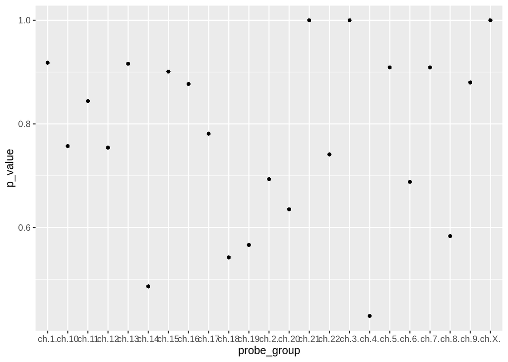

```r
ggplot(p_value_index, aes(x = probe_group, y = p_value)) +
  geom_point(shape=16)
```

In this part j. I split the task into 2 sub-task using future

Comparing to the for-loop method, the future is approximately 2 times faster than the single-thread method. And in the p-value of the T_down, the ch.4. gene group has the smallest p-value, but all of them are greater 0.05, so we can not reject any null hypothesis here.